# Functional Analysis Workshop

Grzegorz Mrukwa

18/07/2021

# Load libraries

```r
library(tidyverse)
library(ggplot2)
library(cowplot)
library(tmod)
library(colorDF)
library(DESeq2)
library(msigdbr)
```

# Load data

```r
counts <- readRDS("data/counts.rds")
covar <- readRDS("data/covar.rds")
annot <- readRDS("data/annot.rds")
```

# Build linear model

```r
ds2 <- DESeqDataSetFromMatrix(countData=counts,
                              colData=covar,
                              design= ~ group)
ds2 <- DESeq(ds2)
```

```
## -- replacing outliers and refitting for 305 genes
## -- DESeq argument 'minReplicatesForReplace' = 7
## -- original counts are preserved in counts(dds)
```

# Comparison

We extract coefficients of the one-vs-one-models which show us the differences between healthy specimens and specific diseases, to compare the change with respect to healthy baseline. We plot logarithm of fold change ratio to check which genes seem concordant (Q1, Q3), and which seem discordant (Q2, Q4).

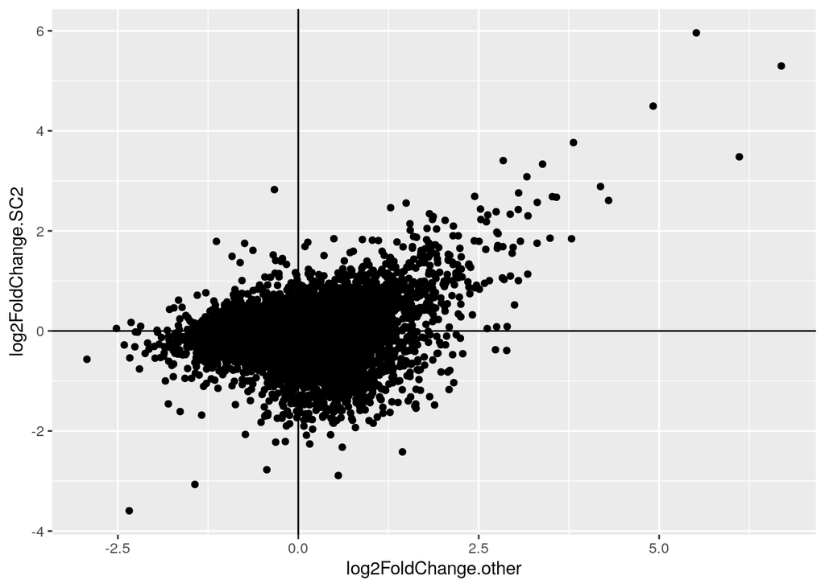

```r
res_other <- results(ds2, name="group_other_vs_no")
res_other <- as.data.frame(res_other)
res_SC2   <- results(ds2, name="group_SC2_vs_no")
res_SC2 <- as.data.frame(res_SC2)
res_merged <- merge(res_other, res_SC2, by=0,
                    suffixes = c(".other", ".SC2"))
ggplot(res_merged, aes(x=log2FoldChange.other, y=log2FoldChange.SC2)) +
  geom_point() + geom_hline(yintercept=0) + geom_vline(xintercept=0)
```

We can also check, how correlated is the change from the healthy condition. Although, correlation usefulness is rather limited, as in most cases test will yield statistically significant. Correlation closer to 1 means more concordant genes, closer to -1 means more discordant.

```r
cor.test(res_merged$log2FoldChange.other, res_merged$log2FoldChange.SC2)
```

```
##
##  Pearson's product-moment correlation
##
## data:  res_merged$log2FoldChange.other and res_merged$log2FoldChange.SC2
## t = 22.54, df = 15977, p-value < 2.2e-16
## alternative hypothesis: true correlation is not equal to 0
## 95 percent confidence interval:
##  0.1604859 0.1905409
## sample estimates:
##       cor
## 0.1755543
```

# Annotating genes from the comparison

This is to resolve the genes from IDs to specific information.

```r
res_other <- merge(annot, res_other, by.x="PrimaryID", by.y=0)
res_other <- res_other %>% arrange(padj)
res_SC2 <- merge(annot, res_SC2, by.x="PrimaryID", by.y=0)
res_SC2 <- res_SC2 %>% arrange(padj)
```

# Plotting sample gene

The second most significant gene for SARS-CoV-2 (and the third most significant for `other` class) is plotted below:

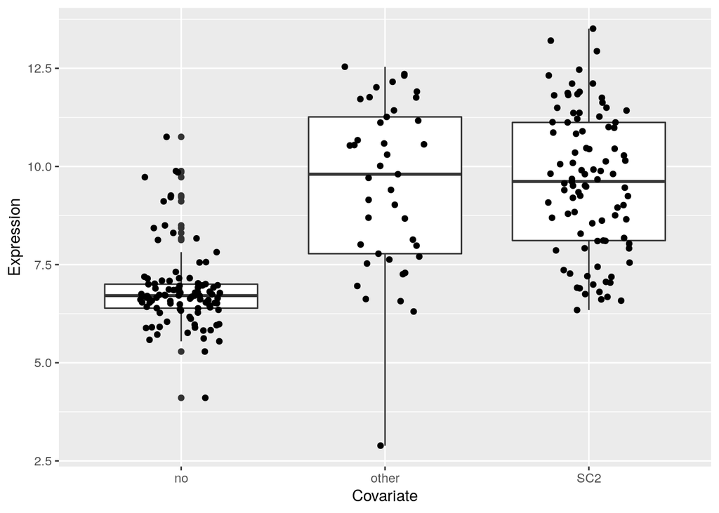

```r
norm_counts <- assay(vst(ds2))

plot_gene <- function(id, expr, covariate) {

  df <- data.frame(Expression=expr[id, ], Covariate=covariate)
  ggplot(df, aes(x=Covariate, y=Expression)) +
    geom_boxplot() +
    geom_jitter(width = .2)
}

plot_gene("ENSG00000185745", norm_counts, covar$group)
```

# Gene set enrichment

These are tests to find the differentially expressed gene sets from the known databases.

## Hypergeometric test and CERNO

Here we require an arbitrarily chosen threshold of significance `0.001` and at least twofold change in gene expression to consider a gene usefulness for a gene set in detecting a disease.

```r
## Hypergeometric test
## define the "foreground" set
pval_thr <- 1e-3 # define the p value threshold
lfc_thr  <- 1    # define the LFC threshold
sel <- abs(res_other$log2FoldChange) > lfc_thr &
       res_other$padj < pval_thr

fg <- res_other$SYMBOL[sel]
bg <- res_other$SYMBOL

hg_res_other <- tmodHGtest(fg=fg, bg=bg)

## CERNO
gg <- res_other$SYMBOL[ order(res_other$pvalue) ]
ce_res_other <- tmodCERNOtest(gg)
```

We sort by the p-value instead of adjusted p-value, since adjusted p-value is monotonic on p-value and it will not change the order. However, adjusted p-value sometimes has a lower resolution (2 different p-values may have the same adjusted p-value due to numerical artifacts).

```r
## Hypergeometric test
sel <- abs(res_SC2$log2FoldChange) > lfc_thr &
       res_SC2$padj < pval_thr

fg <- res_SC2$SYMBOL[sel]
bg <- res_SC2$SYMBOL

hg_res_SC2 <- tmodHGtest(fg=fg, bg=bg)

## CERNO
gg <- res_SC2$SYMBOL[ order(res_SC2$pvalue) ]
ce_res_SC2 <- tmodCERNOtest(gg)
```

And now we compare the differences between enrichment for “other” disease and SARS-CoV-2. The plot below shows just the order of magnitude of the change.

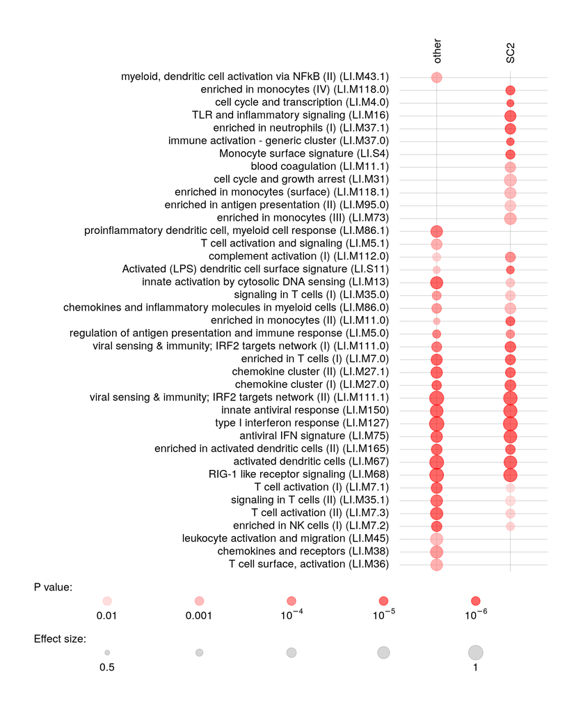

```r
res <- list(other=ce_res_other, SC2=ce_res_SC2)
tmodPanelPlot(res, filter.rows.pval = 1e-3)
```

As we have all genes together before the enrichment, to get differentially expressed ones, we need to review whether there’s concordance or discordance between groups:

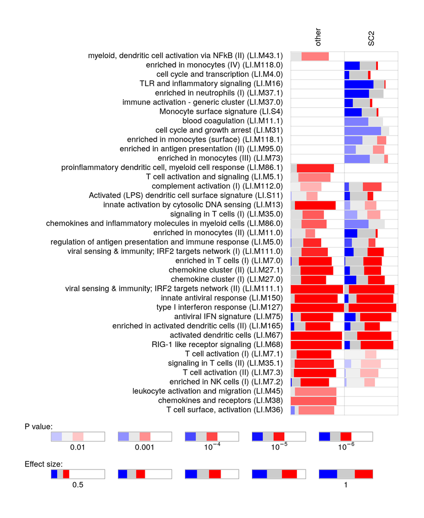

```r
res_merged <- merge(res_other, res_SC2,
  by=c("PrimaryID", "ENSEMBL", "SYMBOL") , suffixes=c(".other", ".SC2"))
lfcs <- res_merged[ , c("log2FoldChange.other", "log2FoldChange.SC2") ]
pvals <- res_merged[ , c("padj.other", "padj.SC2") ]
pie <- tmodDecideTests(res_merged$SYMBOL, lfc = lfcs, pval=pvals)
names(pie) <- names(res)
tmodPanelPlot(res, filter.rows.pval = 1e-3, pie=pie, grid="b")
```

Blue indicates drop in the gene expression level, red – increase.

## What’s the evidence for a gene set to differentiate?

Then, to show whether a specific gene set is justified to be claimed differentiating, one may check effect size related with that gene set. It is equivalent to area under the ROC curve of a gene set, ordered by the p-values. If there’s a dense group of genes with high differentiating potential, it brings AUC closer to 1.

Here we inspect effect size of the group with ID `LI.M75` (antiviral IFN signature) for SARS-CoV-2 vs no disease:

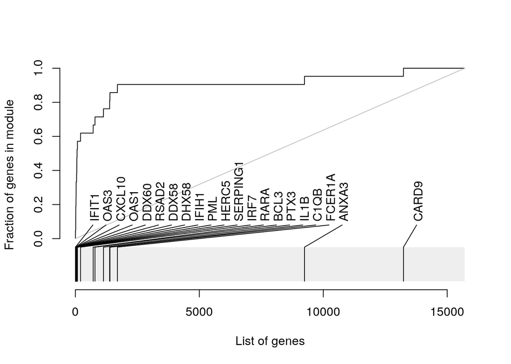

```r
gg <- res_SC2$SYMBOL[ order(res_SC2$pvalue) ]
evidencePlot(gg, m="LI.M75", gene.labels=TRUE)
```

From the previous plot we could already suspect that the AUC could be close to 1. On the contrary, group with ID `LI.M37.0` (immune activation - generic cluster) has AUC much closer to 0.5.

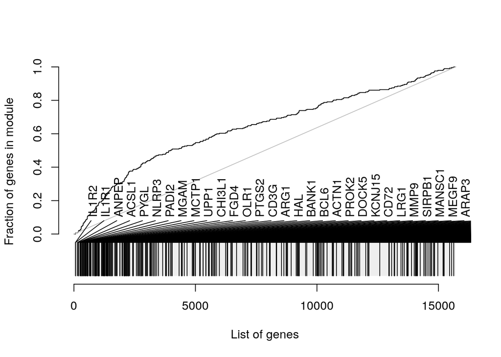

```r
gg <- res_SC2$SYMBOL[ order(res_SC2$pvalue) ]
evidencePlot(gg, m="LI.M37.0", gene.labels=TRUE)
```

## Down the gene set

Finally, we go down the gene set `LI.M75` to the actual genes, to see if these are differentially expressed between SARS-CoV-2 and no disease.

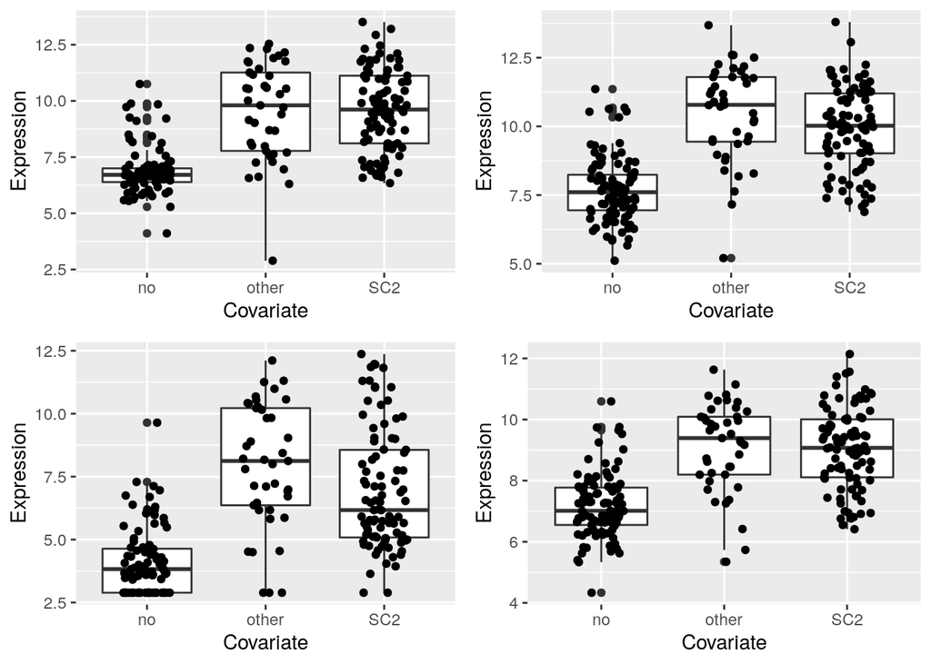

```r
mm <- getModuleMembers("LI.M75")[[1]]
sel <- res_SC2[ res_SC2$SYMBOL %in% mm, ][["PrimaryID"]]
plots <- lapply(sel[1:4], plot_gene, expr=norm_counts, covariate=covar$group)
plot_grid(plotlist=plots, ncol=2)
```

As one can see, these genes are upregulated in SARS-CoV-2 as compared to no disease.